# Analyse des avis et alertes ANSSI — Visualisation & Machine Learning

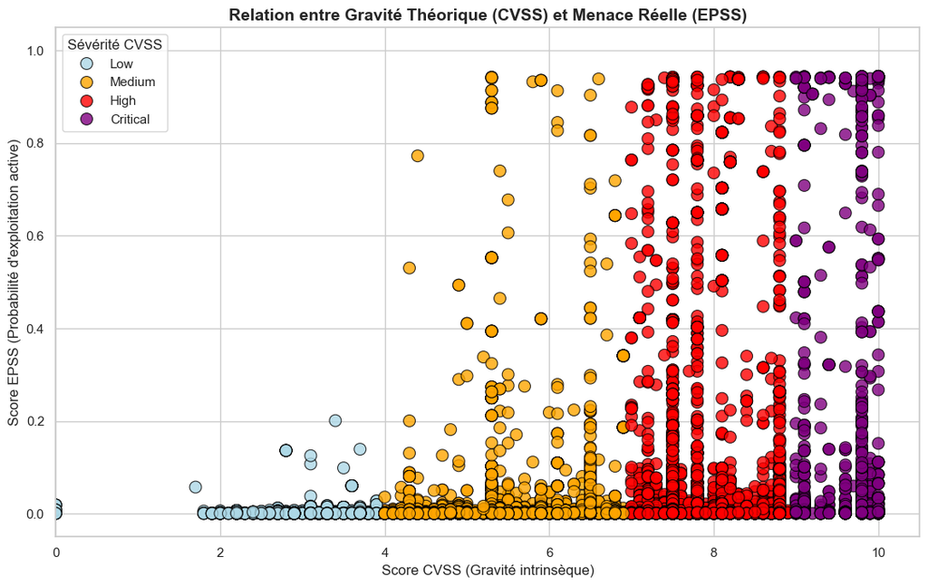

```python
plt.figure(figsize=(11, 7))

# Définition de l'ordre de sévérité et filtrage des valeurs présentes
severity_order = ['Low', 'Medium', 'High', 'Critical']
present_severities = [s for s in severity_order if s in df['base_severity'].unique()]

sns.scatterplot(data=df, x='cvss_score', y='epss_score', hue='base_severity', hue_order=present_severities,
                palette={'Low': 'lightblue', 'Medium': 'orange', 'High': 'red', 'Critical': 'purple'},
                s=100, alpha=0.8, edgecolor='black')

plt.title('Relation entre Gravité Théorique (CVSS) et Menace Réelle (EPSS)', fontsize=14, fontweight='bold')
plt.xlabel('Score CVSS (Gravité intrinsèque)', fontsize=12)
plt.ylabel('Score EPSS (Probabilité d\'exploitation active)', fontsize=12)
plt.xlim(0, 10.5)
plt.ylim(-0.05, 1.05)
plt.legend(title='Sévérité CVSS')
plt.tight_layout()
plt.show()
```

*Le nuage de points révèle une corrélation faible entre gravité théorique (CVSS) et probabilité d'exploitation réelle (EPSS). La majorité des CVE, toutes sévérités confondues, présente un score EPSS proche de zéro — ils ne sont pas exploités activement malgré leur gravité potentielle. Quelques points isolés à EPSS élevé (> 0.5) apparaissent dès les scores CVSS médians (4–6), montrant qu'une faille modérée peut devenir une menace prioritaire si un exploit public existe. Les CVE cumulant CVSS ≥ 9.0 et EPSS élevé, visibles en haut à droite, constituent les menaces de priorité absolue pour les équipes de sécurité.*

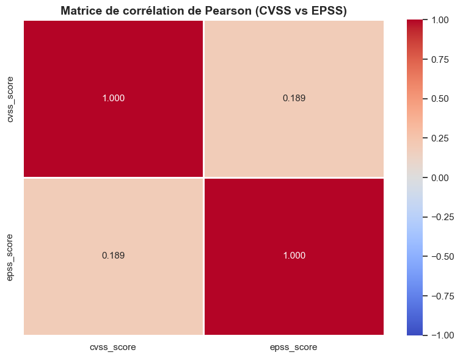

```python
plt.figure(figsize=(8, 6))

# On isole les données numériques pour éviter les erreurs de corrélation sur des chaînes de caractères
corr_matrix = df[['cvss_score', 'epss_score']].corr()

sns.heatmap(corr_matrix, annot=True, cmap='coolwarm', vmin=-1, vmax=1, fmt=".3f", linewidths=1, linecolor='white')
plt.title('Matrice de corrélation de Pearson (CVSS vs EPSS)', fontsize=14, fontweight='bold')
plt.tight_layout()
plt.show()
```

*La corrélation de Pearson entre CVSS et EPSS s'établit à 0.189, confirmant une relation positive mais très faible. Autrement dit, la gravité intrinsèque d'une vulnérabilité n'explique que 3.6% de la variance de sa probabilité d'exploitation (r² = 0.189²). Ce résultat valide l'intérêt d'utiliser conjointement les deux indicateurs : le CVSS seul est insuffisant pour prioriser les actions correctives, et l'EPSS apporte une dimension prédictive indépendante et complémentaire.*

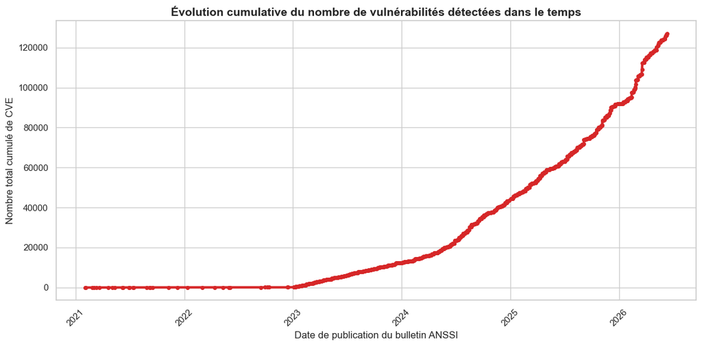

```python
# Groupement par date et tri temporel
df_time = df.sort_values('date').groupby('date').size().reset_index(name='Nombre')
df_time['Cumul'] = df_time['Nombre'].cumsum()

plt.figure(figsize=(12, 6))
plt.plot(df_time['date'], df_time['Cumul'], color='#d62728', linewidth=3, marker='o', markersize=4)

plt.title('Évolution cumulative du nombre de vulnérabilités détectées dans le temps', fontsize=14, fontweight='bold')
plt.xlabel('Date de publication du bulletin ANSSI', fontsize=12)
plt.ylabel('Nombre total cumulé de CVE', fontsize=12)
plt.xticks(rotation=45)
plt.tight_layout()
plt.show()
```

*La courbe cumulative révèle une accélération spectaculaire du nombre de CVE à partir de 2023, avec une pente qui s'accentue nettement en 2025 et 2026. Entre 2021 et 2022, le volume reste quasi nul dans notre dataset — reflet du périmètre des bulletins ANSSI collectés. À partir de 2023, la croissance devient exponentielle, atteignant 127 016 CVE cumulés en juin 2026. Cette tendance illustre l'expansion rapide de la surface d'attaque des systèmes d'information modernes et souligne l'importance croissante d'outils automatisés de veille cybersécurité comme celui développé dans ce projet.*

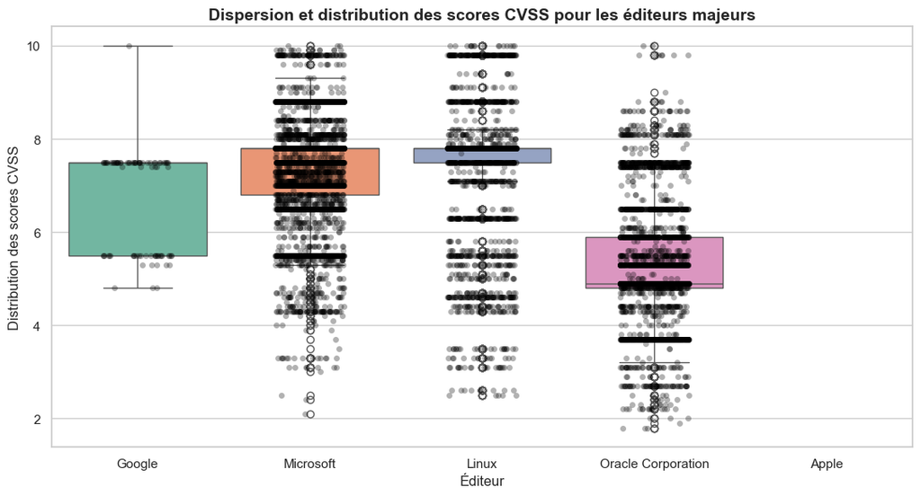

```python
# On cible le Top 5 des éditeurs pour ne pas surcharger le graphe
top_5_editors = df['vendor'].value_counts().head(5).index
df_filtered = df[df['vendor'].isin(top_5_editors)]

plt.figure(figsize=(11, 6))
sns.boxplot(data=df_filtered, x='vendor', y='cvss_score', hue='vendor', palette='Set2', legend=False)
sns.stripplot(data=df_filtered, x='vendor', y='cvss_score', color='black', alpha=0.3, size=5, jitter=0.2)

plt.title('Dispersion et distribution des scores CVSS pour les éditeurs majeurs', fontsize=14, fontweight='bold')
plt.xlabel('Éditeur', fontsize=12)
plt.ylabel('Distribution des scores CVSS', fontsize=12)
plt.tight_layout()
plt.show()
```

## Machine Learning

Quatre modèles testés et comparés — les plus performants sont retenus.

[output not shown]

> `cvss_score` exclu des features de classification : il détermine mécaniquement `base_severity`, ce qui produisait 100% d'accuracy sans apprentissage réel (data leakage corrigé).

**Pourquoi combiner CVSS et EPSS ?**  
Le CVSS mesure la gravité théorique d'une faille — les dégâts potentiels si elle est exploitée. L'EPSS mesure sa probabilité réelle d'exploitation à court terme. Un patch doit être appliqué en priorité absolue quand une faille cumule CVSS élevé **et** EPSS élevé. C'est exactement ce que DBSCAN a isolé : 79 CVE réunissant ces deux critères.

```python
# ==============================================================================
# ÉTAPE 6 — MACHINE LEARNING : IMPORTS
# ==============================================================================

from sklearn.preprocessing import LabelEncoder, StandardScaler
from sklearn.model_selection import train_test_split, cross_val_score
from sklearn.ensemble import RandomForestClassifier, RandomForestRegressor
from sklearn.cluster import KMeans, DBSCAN
from sklearn.decomposition import PCA
from sklearn.neighbors import NearestNeighbors
from sklearn.metrics import (classification_report, ConfusionMatrixDisplay,
                             mean_absolute_error, mean_squared_error, r2_score)
from sklearn.impute import SimpleImputer
from sklearn.utils.class_weight import compute_sample_weight
import xgboost as xgb

print("[+] Bibliothèques ML importées avec succès.")
print(f"    XGBoost version : {xgb.__version__}")
```

```
[+] Bibliothèques ML importées avec succès.
    XGBoost version : 3.2.0
```

```python
# ==============================================================================
# PRÉPARATION DES DONNÉES
# ==============================================================================
# Règle clé : séparer les données AVANT l'imputation pour éviter
# tout data leakage (les statistiques des inconnus ne doivent pas
# influencer les médianes apprises sur les données connues).
# ==============================================================================

# --- Encodage des variables catégorielles ---
le_cwe  = LabelEncoder()
le_type = LabelEncoder()
df['cwe_encoded']  = le_cwe.fit_transform(df['cwe'].fillna('Inconnu'))
df['type_encoded'] = le_type.fit_transform(df['type'].fillna('Avis'))

# --- Features pour la classification et le clustering ---
FEATURES_CLF = ['epss_score', 'cwe_encoded', 'type_encoded']
# Note : cvss_score exclu — détermine mécaniquement base_severity (leakage)

# --- Features pour la régression EPSS ---
FEATURES_REG = ['cvss_score', 'cwe_encoded', 'type_encoded']
# Note : cvss_score inclus ici car la cible est EPSS, pas base_severity

# --- Features pour le clustering (les 4 variables disponibles) ---
FEATURES_CLU = ['cvss_score', 'epss_score', 'cwe_encoded', 'type_encoded']

# --- Séparation AVANT imputation ---
df_connus   = df[df['base_severity'].notna()].copy()
df_inconnus = df[df['base_severity'].isna()].copy()

print(f"CVE avec sévérité connue    : {len(df_connus):>7,}")
print(f"CVE sans sévérité (à prédire): {len(df_inconnus):>7,}")

# --- Imputation sur les données connues → même imputer appliqué aux inconnus ---
imputer_clu = SimpleImputer(strategy='median')
X_clu       = imputer_clu.fit_transform(df_connus[FEATURES_CLU])

imputer_clf = SimpleImputer(strategy='median')
X_clf       = imputer_clf.fit_transform(df_connus[FEATURES_CLF])
X_clf_pred  = imputer_clf.transform(df_inconnus[FEATURES_CLF])

print(f"\nFeatures clustering  : {FEATURES_CLU}")
print(f"Features classif.    : {FEATURES_CLF}")
print(f"Features régression  : {FEATURES_REG}")
```

```
CVE avec sévérité connue    :  27,529
CVE sans sévérité (à prédire):  99,487

Features clustering  : ['cvss_score', 'epss_score', 'cwe_encoded', 'type_encoded']
Features classif.    : ['epss_score', 'cwe_encoded', 'type_encoded']
Features régression  : ['cvss_score', 'cwe_encoded', 'type_encoded']
```